# DPWH Budget Analysis

## 7.2 The 2025 Veto (₱26.1B)

FY2025 repeated the pattern on a smaller scale. Congress raised the DPWH proposal sharply — from a **₱898.9B** NEP to a **₱1,113.8B** legislated total, a **+₱215B** insertion — and the President then vetoed **₱26.1B**, bringing the enacted GAA to **₱1,087.7B**. Where 2019's veto fell on the Local Program, 2025's landed squarely on the two programs most associated with discretionary spending: **Convergence and Special Support (₱18.0B vetoed)** and **Flood Management (₱7.5B)**.

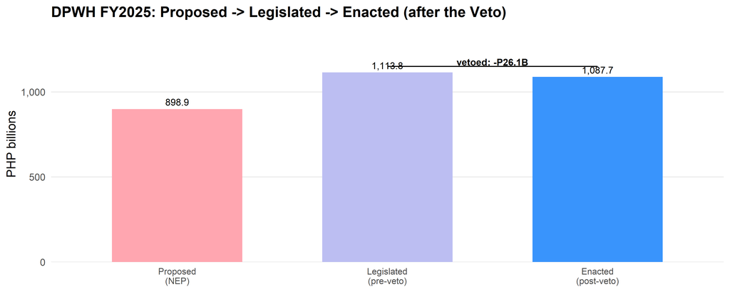

The vetoed amounts fell on three programs, and — as in 2019 — almost entirely on centrally-held appropriations:

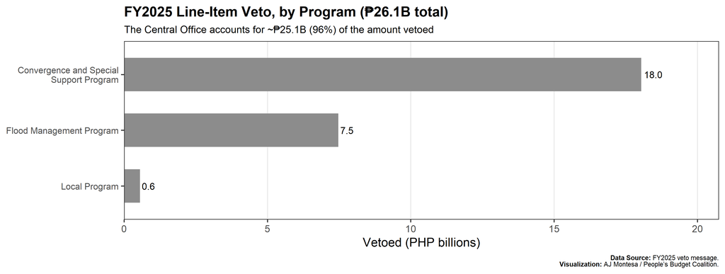

As in 2019, the veto was overwhelmingly a **Central Office** event — about **₱25.1B (96%)** of the ₱26.1B struck was drawn from centrally-held appropriations, with only token amounts removed from named district offices. The recurring story is the same across both years: the largest discretionary build-ups are inserted centrally during deliberations, and it is there that the veto pen, when used, falls.

# 8 DPWH and the Unprogrammed Appropriations

The **Unprogrammed Appropriations (UA)** is a standby fund that may only be released when revenue collections exceed targets or new financing is secured. Because releases happen *outside* the regular program structure, they are harder to track — and the DPWH's draw on the UA has become a focus of scrutiny, as a number of flood-control projects later flagged as questionable were reportedly financed through this route. The table records **allotments released** (the spending authority granted) and **obligations** (amounts actually committed); obligation data before 2013 could not be sourced, and FY2015-2017 carried no UA releases to the DPWH at all.

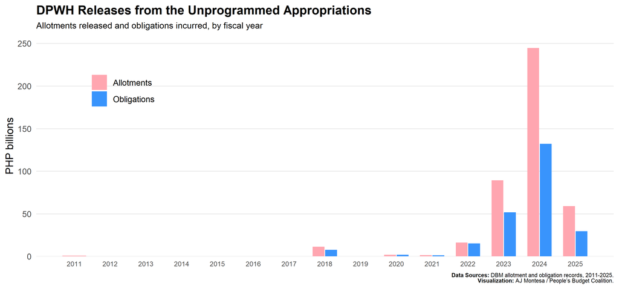

After a decade of negligible draws, UA releases to the DPWH surged from **₱16B in 2022 to ₱89B in 2023 and ₱245B in 2024** — the latter alone roughly a quarter of the department's entire regular budget that year. Yet a large share of these allotments went unobligated (about **54% utilised in 2024**, **50% in 2025**), which — alongside the project-level findings reported elsewhere — is exactly the kind of pattern that merits questioning at the hearings.

DPWH releases from the Unprogrammed Appropriations, PHP billions

| FY | Allotments (B) | Obligations (B) | Utilization |
| --- | --- | --- | --- |
| 2011 | 0.81 | – | – |
| 2012 | 0.02 | – | – |
| 2013 | 0.00 | 0.00 | – |
| 2014 | 0.04 | 0.04 | 99% |
| 2015 | 0.00 | 0.00 | – |
| 2016 | 0.00 | 0.00 | – |
| 2017 | 0.00 | 0.00 | – |
| 2018 | 11.45 | 7.63 | 67% |
| 2019 | 0.01 | 0.01 | 100% |
| 2020 | 1.84 | 1.80 | 97% |
| 2021 | 1.36 | 1.31 | 96% |
| 2022 | 16.26 | 15.11 | 93% |
| 2023 | 89.33 | 51.72 | 58% |
| 2024 | 244.74 | 132.19 | 54% |
| 2025 | 59.08 | 29.62 | 50% |

# 9 Notes

**On coverage.** The Section 1 series is intentionally left with gaps where the physical documents have not yet been encoded; points mark observed years. The by-operating-unit data now runs from the FY2014 budget through FY2026, so the department-wide comparisons span the 16th through 20th Congresses and seven House Speakers (see the Speaker table in the operating-unit section). The district-office deep-dives center on the Duterte and Marcos administrations (FY2017 onward — ten budgets, 2019 included), though the realignments-by-Congress chart reaches back to the 16th Congress (the three Aquino-era budgets) for context. The FY2019 figures use the enacted, post-veto GAA; the ₱95.4B line-item veto that year is isolated in its own chart and section.

**On the 2019 GAA.** The GAA figures throughout are the **enacted, post-veto** levels (they reconcile to the Office-of-the-Secretary totals in Section 1). "Legislated (pre-veto)" reconstructs what Congress passed by adding the vetoed amounts back to the enacted GAA. Because of this, every 2019 realignment figure in this document reflects the *combined* effect of Congress's reallocation and the President's veto, not Congress alone; the veto section, the Central-vs-District veto chart, and the grey segments in the realignments-by-Congress chart isolate the veto and recover Congress's pre-veto intent.

**On the Unprogrammed Appropriations.** UA obligation data before 2013 could not be sourced; FY2015-2017 had no UA releases to the DPWH. These realignments are simply the arithmetic NEP-to-GAA difference and are not, on their own, evidence of irregularity.